# Ford GoBike Dataset Exploration

## by Andrew Ayman

## Investigation Overview

In this investigation, I wanted to look at the characteristics of bike trips that could be used to predict their Duration. The main focus was on the five variables of trips: Distance, Time, User Type,Bike Share and Gender.

## Duration Distribution

Trip durations in the dataset take on a very large range of values, from about 50s at the lowest, to about 80,000s at the highest. Plotted after filtering the outliers, the distribution of trip durations takes on a unimodal shape.

We can see that the durations are Positively(right) Skewed cause mean > median > mode.  
meaning that most trips take approximately 300 seconds (roughly 5 minutes).  
The average trip duration is 550 seconds (roughly 9 minutes).

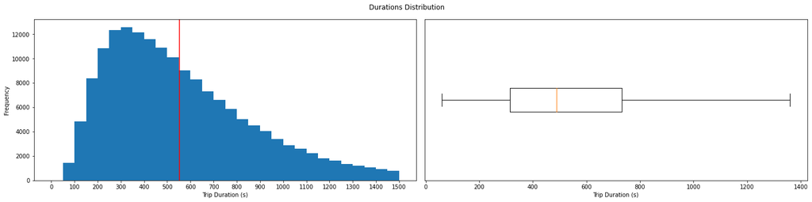

## Time affect on Duration

The hours ranges from 0 (midnight) => 23 (11pm) and days from 1<sup>st</sup> => 28<sup>th</sup> of the month of february 2019.  
First for the time of day as we can see the duration in the early hours are lower than at noon and early night cause traffic and other possible factors.  
The day of the month has nearly no affect on the duration of the trip

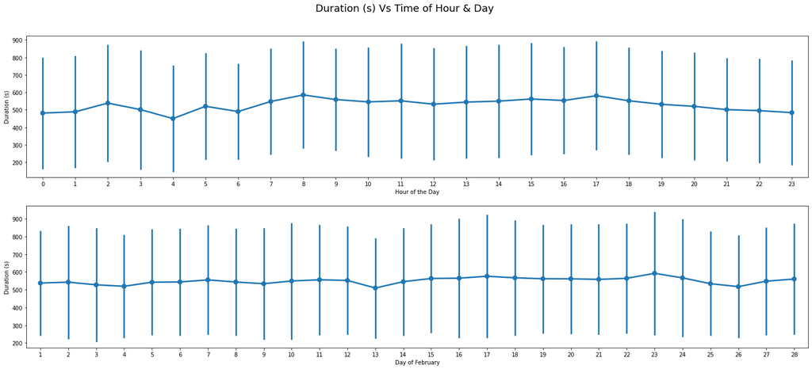

## Affect of Gender, Type, Bike Share on Duration

We see that most subscribers take less time in traveling but they travel less distance so it balances out.  
Most genders approximately take the same amount of time and travel same distance so gender is neutral in cycling.  
50% people who turn off the bike share take more time but they travels a further distance

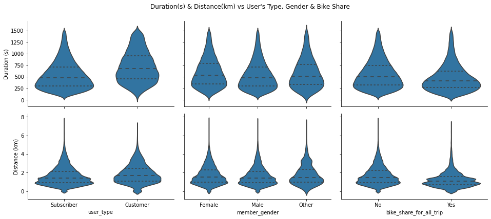